# Benchmarking Poisson regression for exponential growth detection

Adam Howes

Abstract

**Background** Poisson regression is a candidate method for exponential growth detection. The number of k-mers a realistic Nucleic Acid Observatory would process is large. For this reason, it’s important that any candidate methods are assessed for their computational feasibility at scale.

**Task** We will write an R script for performing Poisson regression exponential growth detection on real data. Using code profling and benchmarking tools, we will iterate on the code to improve its computational performance. For the final code, we will produce a summary of the runtime for each line. We will repeat the runtime analysis for varying total numbers of k-mers. We will output an estimated time per e.g. million k-mers.

**Findings**

**Next steps**

```r
knitr::opts_chunk$set(
  echo = TRUE,
  cache = TRUE,
  autodep = TRUE,
  cache.lazy = FALSE,
  cache.comments = FALSE
)

options(scipen = 999)

cbpalette <- multi.utils::cbpalette()

library(tidyverse)
```

## Resources which might be useful

- [23 Measuring performance, Advanced R](https://adv-r.hadley.nz/perf-measure.html)
- [25 Many models, R for Data Science](https://r4ds.had.co.nz/many-models.html)
- [Whassup with `glm()`?, Gelman](https://statmodeling.stat.columbia.edu/2011/05/04/whassup_with_gl/)
- [Handling errors using purrr’s possibly() and safely()](https://aosmith.rbind.io/2020/08/31/handling-errors/)

## Data

We use the `counts` data for this task.

```r
counts <- read.table("data/counts-1pct-sample.tsv", header = TRUE)
subset_length <- 100
subset_counts <- head(counts, n = subset_length)
head(subset_counts)
```

|  | ec | day0 | day1 | day2 | day3 | day4 | day5 | day6 | day7 | day8 | day9 | day10 | day11 | day12 | day13 | day14 | day15 | day16 |
| --- | --- | --- | --- | --- | --- | --- | --- | --- | --- | --- | --- | --- | --- | --- | --- | --- | --- | --- |
| 1 | 0 | 0 | 0 | 1 | 1 | 2 | 2 | 1 | 1 | 0 | 1 | 1 | 2 | 1 | 1 | 1 | 2 | 0 |
| 2 | 1 | 6 | 19 | 20 | 15 | 19 | 10 | 12 | 29 | 13 | 13 | 24 | 16 | 14 | 10 | 8 | 12 | 12 |
| 3 | 2 | 1 | 4 | 5 | 4 | 5 | 6 | 3 | 6 | 3 | 2 | 7 | 2 | 7 | 6 | 2 | 4 | 1 |
| 4 | 3 | 0 | 0 | 1 | 1 | 1 | 1 | 2 | 0 | 0 | 0 | 0 | 3 | 3 | 0 | 0 | 2 | 2 |
| 5 | 4 | 1 | 5 | 6 | 1 | 1 | 9 | 1 | 4 | 4 | 3 | 1 | 1 | 2 | 0 | 4 | 1 | 4 |
| 6 | 5 | 3 | 4 | 1 | 2 | 2 | 0 | 1 | 3 | 1 | 2 | 2 | 0 | 1 | 0 | 0 | 1 | 0 |

## Developing an initial script

### `profvis`

```r
possibly_glm <- possibly(.f = glm, otherwise = NULL)
possibly_tidy <- possibly(.f = broom::tidy, otherwise = NULL)
```

To begin with, we will use `tidyr::pivot_longer` and `stats::glm` to create a function `f` which we can input into `profvis::profvis` to produce a HTML output.

```r
f <- function(df) {
  df_long <- df %>%
  pivot_longer(
    cols = starts_with("day"),
    names_to = "day",
    names_prefix = "day",
    values_to = "count",
    names_transform = list(count = as.integer, day = as.integer)
  )

  fits <- tibble(ec = df$ec)
  fits <- mutate(fits, fit = map(ec, ~possibly_glm(count ~ 1 + day, family = "poisson", data = filter(df_long, ec == .))))
  fits <- mutate(fits, fit = map(fit, possibly_tidy, conf.int = TRUE))
  fits <- unnest(fits, fit)
  return(fits)
}

profvis::profvis(f(subset_counts))
```

[interactive chart not shown]

### `bench`

What about with `bench::mark` instead:

> Benchmark a list of quoted expressions. Each expression will always run at least twice, once to measure the memory allocation and store results and one or more times to measure timing.

#### Pivoting

```r
nrows_experiment <- 10^{1:4}

pivot_bm <- bench::press(
  nrows = nrows_experiment,
  {
    df <- head(counts, n = nrows)
    bench::mark(
      pivot = pivot_longer(
        df,
        cols = starts_with("day"),
        names_to = "day",
        names_prefix = "day",
        values_to = "count",
        names_transform = list(count = as.integer, day = as.integer)
      )
    )
  }
)
```

```
## Running with:
##   nrows
```

```
## 1    10
```

```
## 2   100
```

```
## 3  1000
```

```
## 4 10000
```

```r
pivot_bm
```

```
## # A tibble: 4 × 7
##   expression nrows      min   median `itr/sec` mem_alloc `gc/sec`
##   <bch:expr> <dbl> <bch:tm> <bch:tm>     <dbl> <bch:byt>    <dbl>
## 1 pivot         10   2.47ms   2.61ms      371.   32.09KB     2.13
## 2 pivot        100   2.02ms   2.17ms      442.    92.3KB     2.08
## 3 pivot       1000   2.09ms   2.43ms      409.  693.47KB     2.07
## 4 pivot      10000    3.1ms   3.88ms      244.    6.55MB     4.31
```

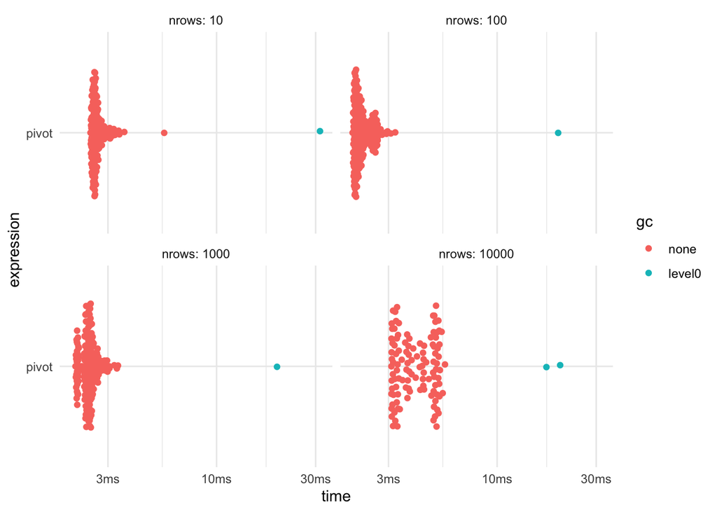

```r
ggplot2::autoplot(pivot_bm)
```

#### Running the generalised linear model

```r
glm_bm <- bench::press(
  nrows = nrows_experiment,
  {
    df <- head(counts, n = nrows)
    df_long <- pivot_longer(
        df,
        cols = starts_with("day"),
        names_to = "day",
        names_prefix = "day",
        values_to = "count",
        names_transform = list(count = as.integer, day = as.integer)
      )

    bench::mark(
      glm = {
        fits <- tibble(ec = df$ec)
        fits <- mutate(fits, fit = map(ec, ~possibly_glm(count ~ 1 + day, family = "poisson", data = filter(df_long, ec == .))))
      }
    )
  }
)
```

```
## Running with:
##   nrows
```

```
## 1    10
```

```
## 2   100
```

```
## 3  1000
```

```
## 4 10000
```

```r
glm_bm
```

```
## # A tibble: 4 × 7
##   expression nrows      min   median `itr/sec` mem_alloc `gc/sec`
##   <bch:expr> <dbl> <bch:tm> <bch:tm>     <dbl> <bch:byt>    <dbl>
## 1 glm           10   47.4ms   51.5ms   16.8      418.8KB    2.10
## 2 glm          100  360.6ms  360.6ms    2.77       6.3MB    2.77
## 3 glm         1000     4.3s     4.3s    0.233    296.1MB    3.03
## 4 glm        10000    49.6s    49.6s    0.0202    25.7GB    0.988
```

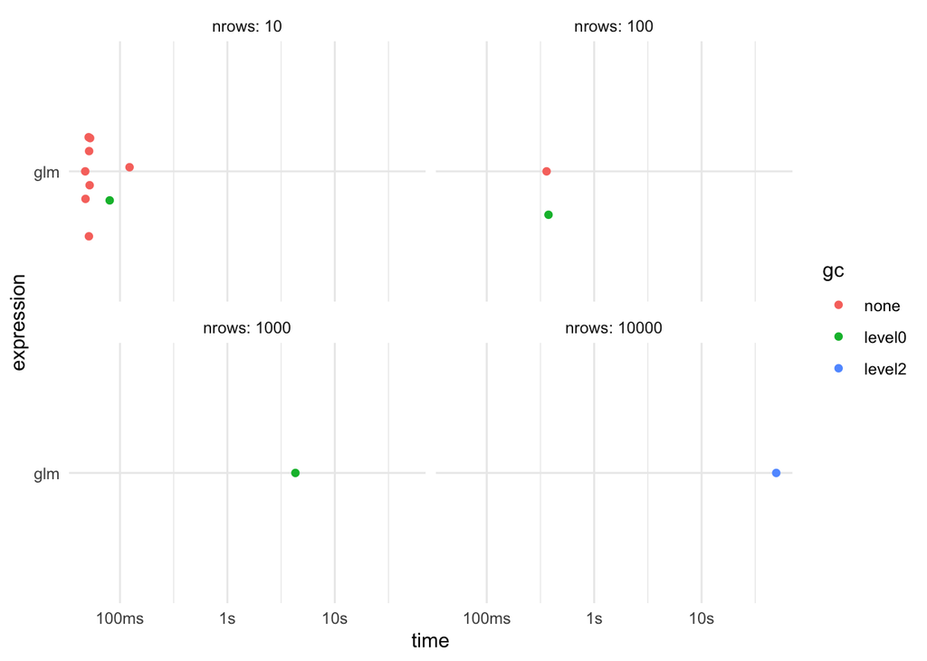

```r
ggplot2::autoplot(glm_bm)
```

#### Tidying the generalised linear model

- The R code for `tidy.glm` is given here: https://github.com/tidymodels/broom/blob/520a933cd84974c42ec3ba8df9a37c59634ce211/R/stats-glm-tidiers.R

```r
before_tidy <- function(nrows) {
  df <- head(counts, n = nrows)
  df_long <- pivot_longer(
    df,
    cols = starts_with("day"),
    names_to = "day",
    names_prefix = "day",
    values_to = "count",
    names_transform = list(count = as.integer, day = as.integer)
  )
  fits <- tibble(ec = df$ec)
  fits <- mutate(fits, fit = purrr::map(ec, ~possibly_glm(count ~ 1 + day, family = "poisson", data = filter(df_long, ec == .))))
  return(fits)
}

tidy_bm <- bench::press(
  nrows = nrows_experiment,
  {
    fits <- before_tidy(nrows = nrows)

    bench::mark(
      tidy = {
        mutate(fits, fit = purrr::map(fit, ~possibly_tidy))
      }
    )
  }
)
```

```
## Running with:
##   nrows
```

```
## 1    10
```

```
## 2   100
```

```
## 3  1000
```

```
## 4 10000
```

```r
tidy_conf_bm <- bench::press(
  nrows = nrows_experiment,
  {
    fits <- before_tidy(nrows = nrows)

    bench::mark(
      tidy_conf = {
        mutate(fits, fit = purrr::map(fit, ~possibly_tidy, conf.int = TRUE))
      }
    )
  }
)
```

```
## Running with:
##   nrows
```

```
## 1    10
```

```
## 2   100
```

```
## 3  1000
```

```
## 4 10000
```

```r
tidy_bm
```

```
## # A tibble: 4 × 7
##   expression nrows      min   median `itr/sec` mem_alloc `gc/sec`
##   <bch:expr> <dbl> <bch:tm> <bch:tm>     <dbl> <bch:byt>    <dbl>
## 1 tidy          10   1.68ms   2.07ms     453.       18KB     0
## 2 tidy         100   1.57ms   1.87ms     497.     18.9KB     0
## 3 tidy        1000   1.64ms   1.89ms     515.     25.9KB     2.05
## 4 tidy       10000  10.13ms  10.98ms      90.1    96.2KB     2.44
```

```r
tidy_conf_bm
```

```
## # A tibble: 4 × 7
##   expression nrows      min   median `itr/sec` mem_alloc `gc/sec`
##   <bch:expr> <dbl> <bch:tm> <bch:tm>     <dbl> <bch:byt>    <dbl>
## 1 tidy_conf     10   1.42ms   1.72ms     568.       18KB     0
## 2 tidy_conf    100   1.13ms   1.19ms     813.     18.9KB     2.10
## 3 tidy_conf   1000   1.68ms   1.73ms     571.     25.9KB     2.49
## 4 tidy_conf  10000  14.19ms  15.82ms      60.2    96.2KB     0
```

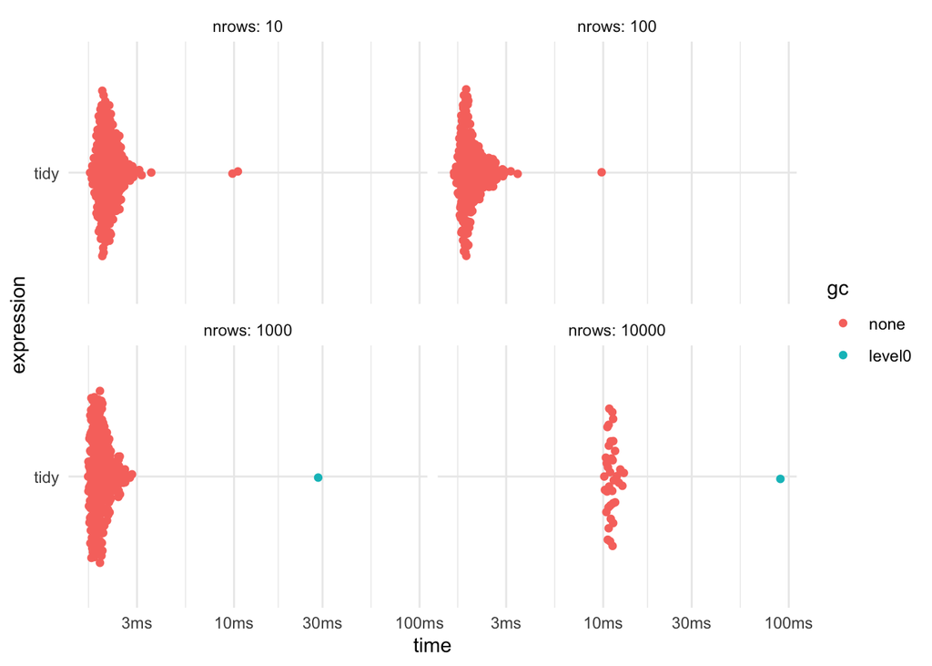

```r
ggplot2::autoplot(tidy_bm)
```

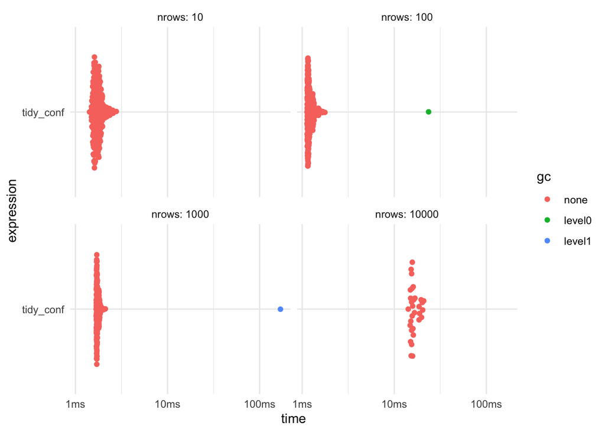

```r
ggplot2::autoplot(tidy_conf_bm)
```

## Ideas and notes for continuation of this document

- Use `?glm` to check what the possible input formats are
  - Could use `filter` (or something more computationally efficient like `[]`) to pick out rows then put them into `glm`
  - Could “hard-code” in the time covariate, as it is the same for every time-series
- Use data.table to do the pivot, how much quicker is that?
- On the order of GB memory is starting to be prohibitive
- What exactly does `mem_alloc` refer to?
- Try forecasting the requirements for each step at different numbers of $k$-mers (just by extrapolation)
- Is `tidy` the slow running thing? Try it without `conf.int = TRUE`
- Is there a way to specify one call to `glm` with inputs `ec` within the formula and gets what we’re aiming for?
- Test running `furrr`